# Homework 1: Data Visualization & Google Trends

#### Batuhan Sarıtaş 2018402153

The aim of this homework is to demonstrate time series manipulation skills by inspecting different data sets and suggesting answers to relevant questions concerning the correlations between them. Three of these data sets are downloaded from EVDS (Electronic Data Delivery System). These are house total sales statistics, surveys conducted showing the probability of buying or building a home over the next 12 months and weighted average interest rates for bank loans for housing from the beginning of 2013 to 2022.

EVDS data is given [here](https://github.com/BU-IE-360/spring22-bthnsrts/blob/gh-pages/IE360/EVDS.xlsx).

Additionally, Google Search trends are used for the last data measurements. Number of google searches with the keyword 'emlak' from the beginning of 2013 to 2022 are scaled between 0 to 100 in this data.

Google Trend data is given [here](https://github.com/BU-IE-360/spring22-bthnsrts/blob/gh-pages/IE360/multiTimeline.csv).

Each question of interest and graphical observations with comments are provided below. Related python codes in .ipynb format are to be found [here](https://github.com/BU-IE-360/spring22-bthnsrts/blob/gh-pages/IE360/IE360-HW1.ipynb).

## Research of Interest

With these data sets imported to the notebook, our main aim is to visualize how google search trend for 'emlak' keyword is correlated with house sales statistics, housing tendency survey and bank interests for house loans. Firstly let us visualize the time series separately.

## 'emlak' search trend in Google over 9 years

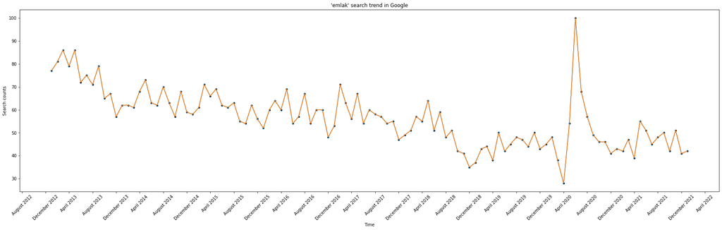

```python
fig, ax = plt.subplots()
fig.set_size_inches(30,8)

ax.plot(trend_data, marker=".", markersize=8, markerfacecolor="black")
time_series_formatter(fig, ax)

ax.set_title("'emlak' search trend in Google")
ax.set_xlabel("Time")
ax.set_ylabel("Search counts")
plt.style.use('ggplot')

plt.plot(trend_data)
plt.show()
```

It should be noted that values are scaled from 0 to 100.

## EVDS House Sales Statistics for 9 years

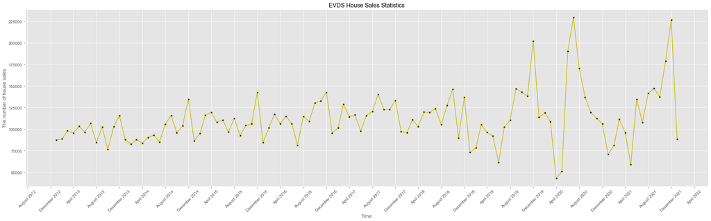

```python
fig, ax = plt.subplots()
fig.set_size_inches(30,8)
ax.plot(evds[['House Sales']], marker=".", markersize=8, markerfacecolor="black", color = 'y')

time_series_formatter(fig, ax)

ax.set_title('EVDS House Sales Statistics')
ax.set_xlabel("Time")
ax.set_ylabel("The number of house sales")
plt.style.use('seaborn')
plt.show()
plt.clf()
```

## EVDS tendency to buy or build a home over the next 12 months survey for 9 years

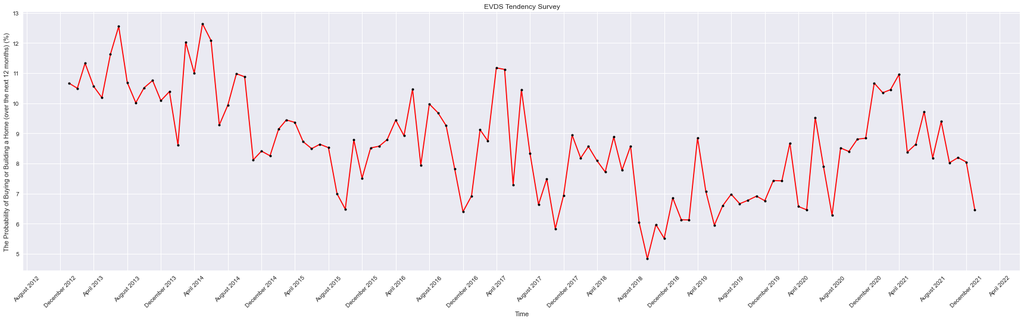

```python
fig, ax = plt.subplots()
fig.set_size_inches(30,8)
ax.plot(evds[['The Probability of Buying or Building a Home']], color = 'r',marker=".", markersize=8, markerfacecolor="black")

time_series_formatter(fig, ax)

ax.set_title('EVDS Tendency Survey')
ax.set_xlabel("Time")
ax.set_ylabel("The Probability of Buying or Building a Home (over the next 12 months) (%)")
plt.style.use('ggplot')
plt.show()
plt.clf()
```

## EVDS Average Bank Interest Rates for Housing Loans for 9 years

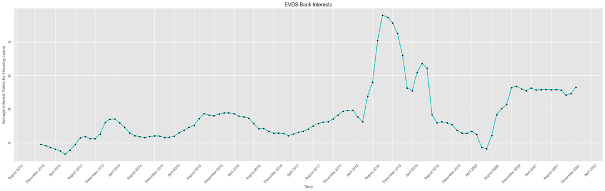

```python
fig, ax = plt.subplots()
fig.set_size_inches(30,8)
ax.plot(evds[['Average Interest Rates for Housing Loans']], color = 'c', marker=".", markersize=8, markerfacecolor="black")

time_series_formatter(fig, ax)

ax.set_title('EVDS Bank Interests')
ax.set_xlabel("Time")
ax.set_ylabel("Average Interest Rates for Housing Loans")
plt.show()
plt.clf()
```

## Question I)

##### It is highly intuitive to suggest that as 'emlak' search trends in Google increase, the number of house sales has the tendency to rise up since buyers are likely to search for house prices and locations on the internet before purchasing. We will check the correlation between these time series by plotting them together firstly. It should be noted that house sales statistics are scaled between 100 and 0 to compare the numericla values with search trends

#### Two time series in a plot

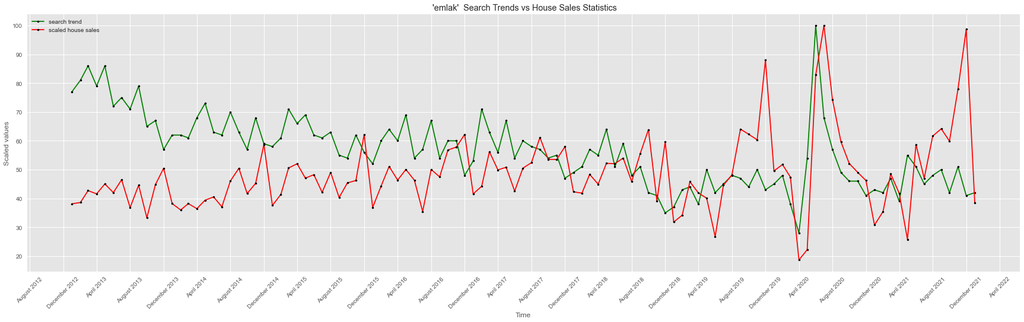

```python
fig, ax = plt.subplots()
fig.set_size_inches(30,8)

scaled_house_sales = pd.DataFrame(100*np.array(evds['House Sales'])/np.array(max(evds['House Sales'])), index = evds.index)
ax.plot(trend_data, color = 'g', label = 'search trend', marker = '.', markersize = 7, markerfacecolor = 'black')
ax.plot(scaled_house_sales, color = 'r', label = 'scaled house sales', marker = '.', markersize = 7, markerfacecolor = 'black')
ax.set_ylabel('Scaled values')
ax.set_xlabel('Time')
ax.set_title(' \'emlak\'  Search Trends vs House Sales Statistics')
plt.legend()

time_series_formatter(fig, ax)
```

##### These time series do not show any significant signs of overlap. However; it should be observed that there is a huge spike in July 2020 for both series. Additionally, series seem to follow same up and down trends. In fact, this observations should be elaborated since existence of any correlation between percentage changes in both data between previous month and current month would be more plausible. So, we will plot percentage changes in both data in a time series and compare them.

#### Fluctuations

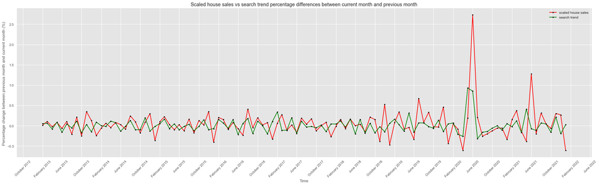

```python
fig, ax = plt.subplots()
fig.set_size_inches(30,8)
time_series_formatter(fig, ax)

ax.plot(diff_scaled_house_sales, color ='r', label = 'scaled house sales', marker = '.', markerfacecolor = 'black')
ax.plot(diff_trend_data , color ='g', label = 'search trend', marker = '.', markerfacecolor = 'black')

ax.set_ylabel('Percentage change between previous month and current month (%) ')
ax.set_xlabel('Time')
ax.set_title('Scaled house sales vs search trend percentage differences between current month and previous month')
plt.legend()
```

##### Now, existence of a correlation between percentage change in house sales and search trend is more visible. House sales are relatively more unstable and show higher peaks. However, percentage change series show pretty similar behaviour until the year 2019. After then, percentage change in house sales show extreme deviations. This might result from the volatility of house sales compared to google searches due to economic conditions and exchange rate crisis after 2018. Although both series follow similar trends, changes in the sales between following months are higher.

##### Now, we will plot boxplots for each time series grouping them by years. Boxplots will help us visualize and compare volatility and variability of both series

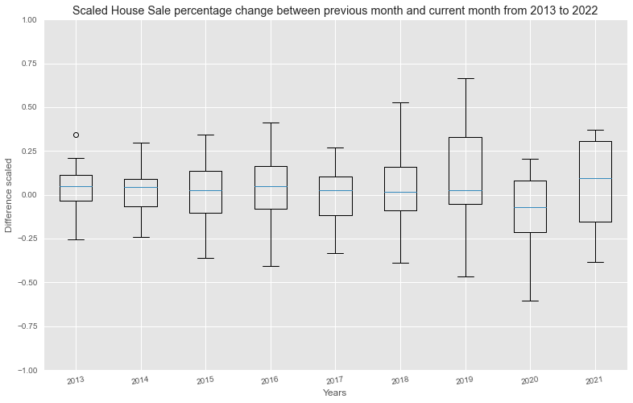

```python
fig, ax = plt.subplots()
fig.set_size_inches(13,8)

ax.boxplot(diff_scaled_house_sales_years.fillna(diff_trend_data_years.iloc[:,0].mean()))
plt.xticks([1, 2, 3, 4, 5, 6, 7, 8, 9], ["2013", "2014", "2015", "2016", '2017', '2018', '2019', '2020', '2021'], rotation=10)
ax.set_title('Scaled House Sale percentage change between previous month and current month from 2013 to 2022')
ax.set_xlabel('Years')
ax.set_ylabel('Difference scaled')

plt.ylim(-1, 1)

plt.show()
plt.clf()
```

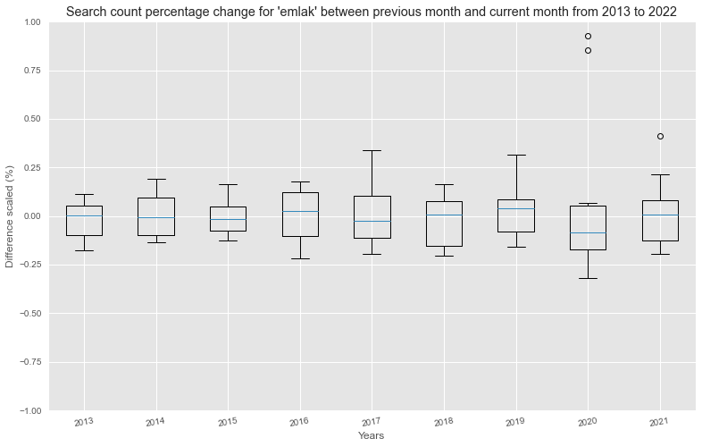

```python
fig, ax = plt.subplots()
fig.set_size_inches(13,8)

ax.boxplot(diff_trend_data_years.fillna(diff_trend_data_years.iloc[:,0].mean()))
plt.xticks([1, 2, 3, 4, 5, 6, 7, 8, 9], ["2013", "2014", "2015", "2016", '2017', '2018', '2019', '2020', '2021'], rotation=10)
ax.set_title('Search count percentage change for \'emlak\' between previous month and current month from 2013 to 2022')
ax.set_xlabel('Years')
ax.set_ylabel('Difference scaled (%)')

plt.ylim(-1, 1)

plt.show()
```

## Question II)

##### Do google trends correlate with surveys conducted about the tendency to buy or build a house over the next 12 months? One could suggest that as the probability of purchasing households increase (according to the surveys conducted), search trends would increase and vice versa. Let us check this by firstly plotting two time series together, with probability values scaled between 1 and 100.

#### Two series in a plot

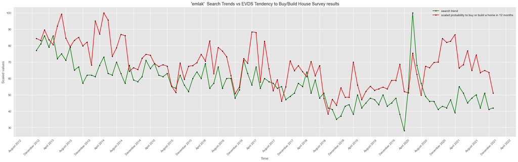

```python
fig, ax = plt.subplots()
fig.set_size_inches(30,8)

scaled_prob = pd.DataFrame(100*np.array(evds['The Probability of Buying or Building a Home'])/np.array(max(evds['The Probability of Buying or Building a Home'],)), index = evds.index)

ax.plot(trend_data, color = 'g', label = 'search trend', marker = '.', markersize = 7, markerfacecolor = 'black')
ax.plot(scaled_prob, color = 'r', label = 'scaled probability to buy or build a home in 12 months', marker = '.', markersize = 7, markerfacecolor = 'black')
ax.set_ylabel('Scaled values')
ax.set_xlabel('Time')
ax.set_title(' \'emlak\'  Search Trends vs EVDS Tendency to Buy/Build House Survey results')
plt.legend()

time_series_formatter(fig, ax)
```

##### Similar to the previous foundings, although numerical values differ significantly, one could suggest a correlation between the up and down trends in search trends and probabilities to buy or build household. These similarities are noticable between mid-2014 to 2017. Peaks are much higher in probabilities once again, which is expectable due to the volatility in house sales. There is an unexpected difference between both trends after August 2020 which would require further investigation. On the other hand, we'd like to inspect the relation between these series further by checking the scatterplot created by both data.

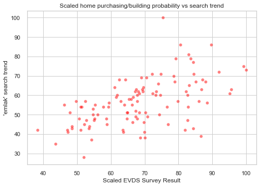

```python
sns.set(style='whitegrid')
sns.scatterplot(x = np.array(scaled_prob.prob), y = np.array(trend_data.search_count), color='red', alpha=0.5)

plt.title('Scaled home purchasing/building probability vs search trend')
plt.xlabel('Scaled EVDS Survey Result')
plt.ylabel('\'emlak\' search trend')


plt.show()
plt.clf()
```

## Question III)

##### One would suggest a relation between bank interest rates on housing loans and house sales statistics. Data such as house sales are highly volatile and we've observed that bank interest show relatively stable trends. Thus, a strict correlation might be far from reality. Yet, it might prove to be useful to compare both trends to analyze whether there is a negative correlation between them as it is expected to observe low number of sales for months with high average interest rates. Let us plot both time series.

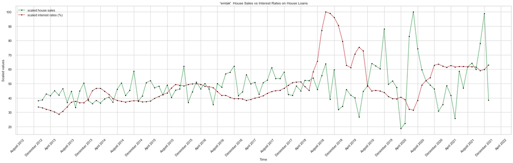

```python
fig, ax = plt.subplots()
fig.set_size_inches(30,8)

scaled_interests = pd.DataFrame(100*np.array(evds['Average Interest Rates for Housing Loans'])/np.array(max(evds['Average Interest Rates for Housing Loans'])), index = evds.index)
ax.plot(scaled_house_sales, color = 'g', label = 'scaled house sales', marker = '.', markersize = 7, markerfacecolor = 'black')
ax.plot(scaled_interests, color = 'r', label = 'scaled interest rates (%)', marker = '.', markersize = 7, markerfacecolor = 'black')
ax.set_ylabel('Scaled values')
ax.set_xlabel('Time')
ax.set_title(' \'emlak\'  House Sales vs Interest Rates on House Loans')
plt.legend()

time_series_formatter(fig, ax)
plt.show()
plt.clf()
```

##### As expected house sales show high variance compared to interest rates. Probably house sales are dependent on so many external factors so that interests on housing loans show not much correlation with sales trends when plotted together. It would be interesting to observe how average sales and average interests for periods of 6 months act together. In order to visualize this, we will use bar plots.

[figure not shown]

```python
fig, ax = plt.subplots()
fig.set_size_inches(30,8)
X =  range(len(scaled_house_sales_rolled.dropna()))
X_axis = np.arange(len(X))

ax.bar(X_axis + 0.2, scaled_house_sales_rolled.sales.dropna(), 0.4, label = 'search trend')
ax.bar(X_axis - 0.2, scaled_interests_rolled.interest.dropna(),  0.4,  label = 'scaled interest rates (%)',tick_label = ['the 1st half 2013','the 2nd half 2013','the 1st half 2014','the 2nd half 2014','the 1st half 2015','the 2nd half 2015','the 1st half 2016','the 2nd half 2016','the 1st half 2017','the 2nd half 2017',
               'the 1st half 2018','the 2nd half 2018','the 1st half 2019','the 2nd half 2019','the 1st half 2020','the 2nd half 2020','the 1st half 2021','the 2nd half 2021'])
ax.set_ylabel('Scaled values')
ax.set_xlabel('Time')
ax.set_title('House Sales vs Interest Rates on House Loans as averages of half years')

for tick in ax.get_xticklabels():
        tick.set_rotation(45)

plt.legend()
plt.show()
```

##### What we would expect from such graph is to observe a contrast between the bars plotted for such series. In fact, one could suggest such contrast from 2013 to the second half of 2016. From then on, both bars show strange behaviour until the second half of 2020. Again, these data might be correlated negatively, however; there must be more important factors that fluctuate the house sales.

## Conclusion

#### It is justifiable to claim that there is a positive correlation between google search trends for "emlak" keyword and house sales. However, house sales statistics are highly volatile and there are many other factors that have a role in this time series. Secondly, an exact correlation between probability of housing and search trend might not sound realistic. Fluctuations seem to have similar patterns. Lastly, we've compared interest rates and house sales statistics. Again, house sales statistics show pretty volatile behaviour compared to the interests. One could suggest a negative correlation by looking at the first half of the barplot, however; second half shows strange behaviour for both time series. In conclusion, house sales are not highly correlated with interest rates but these rates could be a quality indicator for sales predictions.